# DS311 Data Explore

Gabrielle Salamanca

March 28, 2023

## We-R-Finished Project

### 1. Loading necessary libraries & reading dataset into R

```
## [1] 167278     27
```

### 2. Renaming columns for sake of ease

```
##  [1] "Case Number"            "Case Status"            "Received Date"
##  [4] "Decision Date"          "Employer Name"          "Submitted Prevail Wage"
##  [7] "SPrW Unit"              "Submitted Paid Wage"    "SPaW Unit"
## [10] "Job Title"              "Work City"              "Required Edu"
## [13] "Required College Major" "Exp Req"                "Exp Req (Months)"
## [16] "Citizenship"            "Prevail Wage SOC Code"  "PWSOC Title"
## [19] "Work State"             "WS Abb"                 "WPostal Code"
## [22] "Full Time"              "Visa Class"             "Prevail Wage/Yr"
## [25] "Paid Wage/Yr"           "Job Title Sub"          "Order"
```

### 3. What are the job title subcategories & their numbers

```
##   assistant professor              attorney      business analyst
##                 18866                  1488                 27811
##          data analyst        data scientist management consultant
##                  3840                  1227                   770
##     software engineer               teacher
##                 99364                 13912
```

```
##                 Sub_Job Frequency
## 1     Software Engineer     99364
## 2      Business Analyst     27811
## 3        Assistant Prof     18866
## 4               Teacher     13912
## 5        Data Scientist      1227
## 6          Data Analyst      3840
## 7              Attorney      1488
## 8 Management Consultant       770
```

Was expecting higher number of data scientist and analyst Not expecting assistant professor & teacher in top 5

```
##          NEW YORK     MOUNTAIN VIEW     SAN FRANCISCO         SAN DIEGO
##              6714              6712              6458              2983
##          SAN JOSE           HOUSTON       SANTA CLARA           ATLANTA
##              2925              2857              2684              2388
##           CHICAGO            DALLAS         SUNNYVALE         PALO ALTO
##              2351              2277              2198              2145
##            AUSTIN            IRVING            BOSTON       JERSEY CITY
##              1554              1410              1401              1257
##        MENLO PARK           SEATTLE        WASHINGTON        PITTSBURGH
##              1188              1146              1134              1132
##           REDMOND          BELLEVUE       LOS ANGELES NORTH KANSAS CITY
##              1127              1116               986               932
##        PISCATAWAY          COLUMBUS        ALPHARETTA         BALTIMORE
##               919               911               904               879
##             PLANO          San Jose         SAN MATEO           PHOENIX
##               855               829               816               812
##           FREMONT            IRVINE          RICHMOND      REDWOOD CITY
##               800               768               757               755
##         CHARLOTTE       SAN ANTONIO            EDISON     Mountain View
##               749               728               716               697
##      PHILADELPHIA         CAMBRIDGE          BROOKLYN            DURHAM
##               697               692               678               662
##            NEWARK         PRINCETON             TAMPA        RICHARDSON
##               656               631               627               624
##         CUPERTINO      INDIANAPOLIS        WILMINGTON       FOSTER CITY
##               606               599               587               570
##        SCHAUMBURG           HERNDON         HILLSBORO       BLOOMINGTON
##               562               557               557               542
##          MILPITAS            RESTON          COLUMBIA       MINNEAPOLIS
##               538               536               528               527
##           WALTHAM  SOUTH PLAINFIELD           FAIRFAX             MIAMI
##               510               506               498               472
##            MCLEAN         SAN BRUNO         ST. LOUIS  FARMINGTON HILLS
##               470               461               445               438
##       KANSAS CITY            FRISCO          STERLING      JACKSONVILLE
##               432               431               422               408
##          PORTLAND        PLEASANTON           RALEIGH            DENVER
##               408               383               381               372
##         NASHVILLE          CHANDLER           MADISON              TROY
##               372               370               363               359
##            WARREN        BURLINGTON         San Diego          SOMERSET
##               356               349               348               348
##           DETROIT      GAITHERSBURG        CINCINNATI       Santa Clara
##               340               336               334               329
##      SANTA MONICA             OMAHA            DUBLIN         MILWAUKEE
##               326               324               314               312
##         SAN RAMON           ASHBURN        FORT WORTH         ROCHESTER
##               308               306               306               305
##            ALBANY          GLENDALE         ARLINGTON           (Other)
##               304               299               298             70689
```

[output not shown]

Not surprised NY and CA areas are in top 5 cities Expected LA to be in top Wait i didn’t expect to see my city, but it sure is a lot of CA areas

### 4. Who are the top 10 employers

```
##                                     GOOGLE INC.
##                                            6213
##                           FUJITSU AMERICA, INC.
##                                            1814
##                               INTEL CORPORATION
##                                            1781
##                           MICROSOFT CORPORATION
##                                            1364
##                     QUALCOMM TECHNOLOGIES, INC.
##                                            1277
##                                  FACEBOOK, INC.
##                                            1210
##                              CERNER CORPORATION
##                                            1038
##                             CISCO SYSTEMS, INC.
##                                            1011
##                  HITACHI CONSULTING CORPORATION
##                                             812
##              DALLAS INDEPENDENT SCHOOL DISTRICT
##                                             808
##                                 EMC CORPORATION
##                                             789
##                                 IBM CORPORATION
##                                             762
##                                    VMWARE, INC.
##                                             701
##                       IBM INDIA PRIVATE LIMITED
##                                             694
##                LARSEN & TOUBRO INFOTECH LIMITED
##                                             679
##                       WAL-MART ASSOCIATES, INC.
##                                             674
##                            LINKEDIN CORPORATION
##                                             637
##                                   TWITTER, INC.
##                                             632
##                   YASH & LUJAN CONSULTING, INC.
##                                             629
##                       CAPITAL ONE SERVICES, LLC
##                                             526
```

[output cut: 145 more lines]

```
##                                             175
##                   TECH MAHINDRA (AMERICAS),INC.
##                                             174
##                           UNIVERSITY OF FLORIDA
##                                             173
##                            RJT COMPUQUEST, INC.
##                                             171
##                                  ASTA CRS, INC.
##                                             168
##             LOS ANGELES UNIFIED SCHOOL DISTRICT
##                                             167
##                   MIRACLE SOFTWARE SYSYTEMS INC
##                                             164
##                                         (Other)
##                                          123034
```

[output not shown]

We know Google, Intel, Microsoft, Facebook, Cisco. The others I don’t recognize. Also Dallas Independent School District is one of the top 10 employers?

### 5. Top 10 states to work in

```
##                  Alabama                   Alaska                  Arizona
##                      559                       66                     2570
##                 Arkansas               California                 Colorado
##                      558                    46782                     1614
##              Connecticut                 Delaware     District of Columbia
##                     2023                      874                     1370
##                  Florida                  Georgia                     Guam
##                     4064                     5615                       61
##                   Guamam                   Hawaii                    Idaho
##                        1                      170                      186
##                 Illinois                  Indiana                     Iowa
##                     7411                     1617                     1012
##                   Kansas                 Kentucky                Louisiana
##                      746                      641                      883
##                    Maine                 Maryland            Massachusetts
##                      216                     3275                     6848
##                 Michigan                Minnesota              Mississippi
##                     3844                     2116                      343
##                 Missouri                  Montana                 Nebraska
##                     2773                       63                      598
##                   Nevada            New Hampshire               New Jersey
##                      427                      427                    10198
##               New Mexico                 New York           North Carolina
##                      575                    11373                     3578
##             North Dakota Northern Mariana Islands                     Ohio
##                      138                       58                     3192
##                 Oklahoma                   Oregon                    Palau
##                      551                     1535                        1
##             Pennsylvania              Puerto Rico             Rhode Island
##                     4725                      109                      528
##           South Carolina             South Dakota                Tennessee
##                      851                      105                     1087
##                    Texas                     Utah                  Vermont
##                    15498                      757                      131
##           Virgin Islands                 Virginia               Washington
##                      109                     6031                     4610
##            West Virginia                Wisconsin                  Wyoming
##                      307                     1433                       45
```

[output not shown]

as expected CA is the largest, but WOW did the numbers really vary after. I was expecting TX and NY, but def not NJ.

### 6. Top 10 Jobs

```
##                                SOFTWARE ENGINEER
##                                            54478
##                                 BUSINESS ANALYST
##                                            19516
##                         SENIOR SOFTWARE ENGINEER
##                                            11714
##                              ASSISTANT PROFESSOR
##                                            10134
##                                Software Engineer
##                                             3743
##                            SR. SOFTWARE ENGINEER
##                                             2133
##         COMPUTER SOFTWARE ENGINEER, APPLICATIONS
##                                             1808
##                                          TEACHER
##                                             1566
##                                     DATA ANALYST
##                                             1524
##                          SENIOR BUSINESS ANALYST
##                                             1437
##                          STAFF SOFTWARE ENGINEER
##                                             1335
##                     ELEMENTARY BILINGUAL TEACHER
##                                             1020
##                       COMPUTER SOFTWARE ENGINEER
##                                              982
##                      PRINCIPAL SOFTWARE ENGINEER
##                                              962
##                         Senior Software Engineer
##                                              862
##                     RESEARCH ASSISTANT PROFESSOR
##                                              809
##                             SOFTWARE ENGINEER II
##                                              800
##                                   DATA SCIENTIST
##                                              762
##                              Assistant Professor
##                                              678
##                           LEAD SOFTWARE ENGINEER
##                                              658
```

[output cut: 145 more lines]

```
##                                              100
##                   ASSISTANT PROFESSOR OF FINANCE
##                                               96
##                        CLINICAL BUSINESS ANALYST
##                                               96
##                   INTERNATIONAL BUSINESS ANALYST
##                                               95
##                    SENIOR .NET SOFTWARE ENGINEER
##                                               95
##               SENIOR SOFTWARE ENGINEER DEVELOPER
##                                               95
##          ASSISTANT PROFESSOR OF COMPUTER SCIENCE
##                                               92
##                                          (Other)
##                                            32745
```

```
##                               top10  freq
## 1                 Software Engineer 58221
## 2                  Business Analyst 19516
## 3              Sr Software Engineer 13847
## 4               Assistant Professor 10134
## 5  Computer Software Engineer, Apps  1808
## 6                           Teacher  1566
## 7                      Data Analyst  1524
## 8               Sr Business Analyst  1437
## 9           Staff Software Engineer  1335
## 10     Elementary Bilungual Teacher  1020
```

Dataset separated the ones with different cases, had to add up a few. Wasn’t expecting teachers, esp the last one. engineer and analyst are popular jobs it seems

```
##    Min. 1st Qu.  Median    Mean 3rd Qu.    Max.
##   10500   63000   78600   85533  100006 2500000
```

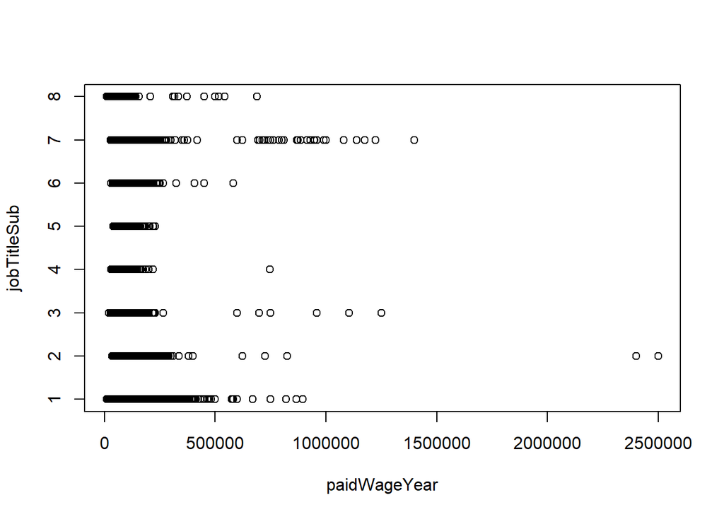

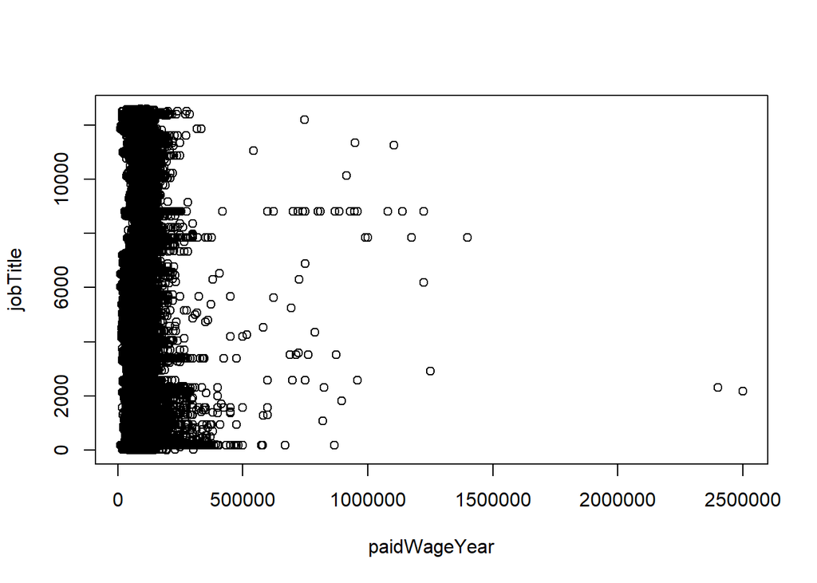

Norm seems to be under $500,000 wage/year. If only the table can tell me which sub jobs they were… I will need to revisit the jobTitle one, but the norm still holds.

### 7. Trying the plots again

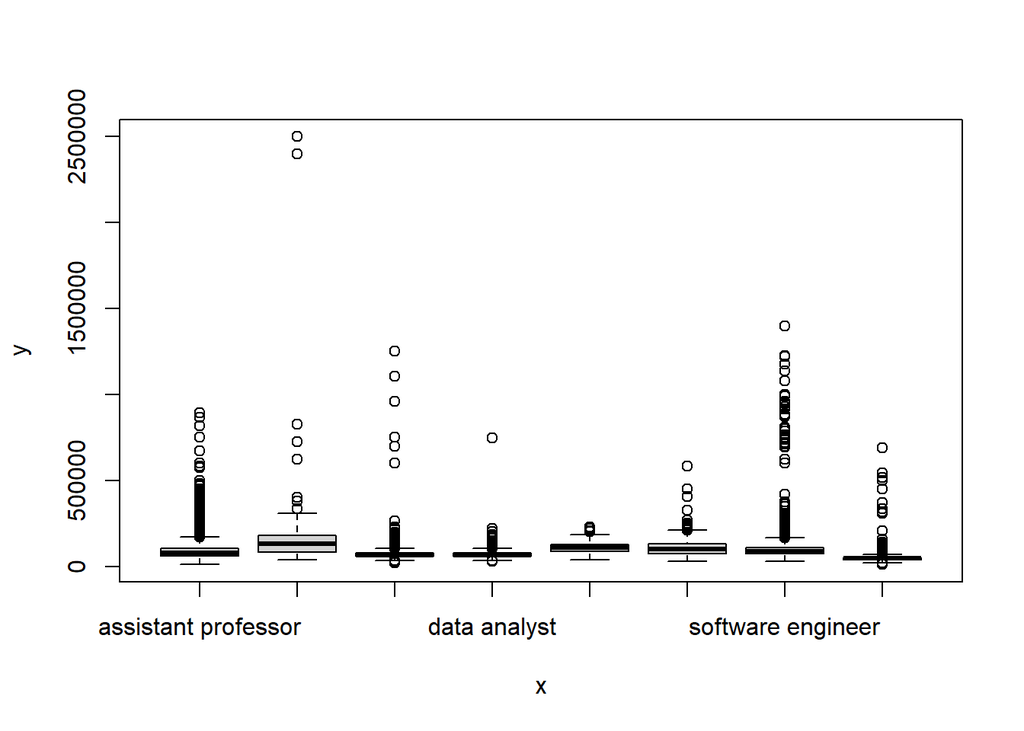

Hard to read

```r
knitr::opts_chunk$set(echo = FALSE)
# loading libraries
library(readxl)
library(caret)
library(ggplot2)
library(dplyr)

# dataset overview
salary <- read_excel("C:/Users/knigh/OneDrive/Desktop/Github/We-R-Finished/salary/salary_data_states.xlsx")
dim(salary)
# renaming
colnames(salary)[1] = "Case Number"
colnames(salary)[2] = "Case Status"
colnames(salary)[3] = "Received Date"
colnames(salary)[4] = "Decision Date"
colnames(salary)[5] = "Employer Name"
colnames(salary)[6] = "Submitted Prevail Wage"
colnames(salary)[7] = "SPrW Unit"
colnames(salary)[8] = "Submitted Paid Wage"
colnames(salary)[9] = "SPaW Unit"
colnames(salary)[10] = "Job Title"
colnames(salary)[11] = "Work City"
colnames(salary)[12] = "Required Edu"
colnames(salary)[13] = "Required College Major"
colnames(salary)[14] = "Exp Req"
colnames(salary)[15] = "Exp Req (Months)"
colnames(salary)[16] = "Citizenship"
colnames(salary)[17] = "Prevail Wage SOC Code"
colnames(salary)[18] = "PWSOC Title"
colnames(salary)[19] = "Work State"
colnames(salary)[20] = "WS Abb"
colnames(salary)[21] = "WPostal Code"
colnames(salary)[22] = "Full Time"
colnames(salary)[23] = "Visa Class"
colnames(salary)[24] = "Prevail Wage/Yr"
colnames(salary)[25] = "Paid Wage/Yr"
colnames(salary)[26] = "Job Title Sub"
colnames(salary)[27] = "Order"
names(salary)
jobTitleSub <- as.factor(salary$`Job Title Sub`)
summary(jobTitleSub)
# dataframe
Sub_Job <- c("Software Engineer", "Business Analyst", "Assistant Prof", "Teacher",
            "Data Scientist", "Data Analyst", "Attorney", "Management Consultant")
Frequency <- c(99364, 27811, 18866, 13912, 1227, 3840, 1488, 770)
job2 <- data.frame(Sub_Job, Frequency)
print(job2)
city <- as.factor(salary$`Work City`)
summary(city)
top10 <- c("New York", "Mountain View", "San Francisco", "San Diego", "San Jose", "Houston", "Santa Clara", "Atlanta", "Chicago", "Dallas")
freq <- c(6714, 6712, 6458, 2983, 2925, 2957, 2684, 2388, 2351, 2277)
topCity <- data.frame(top10, freq)
print(topCity)
employName <- as.factor(salary$`Employer Name`)
summary(employName)
top10 <- c("Google Inc.", "Fujitsu America, Inc.", "Intel Corporation",
           "Microsoft Corporation", "Qualcomm Technologies, Inc.", "Facebook, Inc.",
           "Cerner Corporation", "Cisco Systems, Inc.", "Hitachi Consulting Corporation", "Dallas Independent School District")
freq <- c(6213, 1814, 1781, 1364, 1277, 1210, 1038, 1011, 812, 2277)
topEmploy <- data.frame(top10, freq)
print(topEmploy)
state <- as.factor(salary$`Work State`)
summary(state)
top10 <- c("California", "Texas", "New York", "New Jersey", "Illinois",
           "Massachussets", "Virgina", "Pennsylvania", "Washington", "Michigan")
freq <- c(46782, 15498, 11373, 10198, 7411, 6848, 6031, 4725, 4610, 3844)
topState <- data.frame(top10, freq)
print(topState)
jobTitle <- as.factor(salary$`Job Title`)
summary(jobTitle)
top10 <- c("Software Engineer", "Business Analyst", "Sr Software Engineer", "Assistant Professor", "Computer Software Engineer, Apps",
           "Teacher", "Data Analyst", "Sr Business Analyst", "Staff Software Engineer", "Elementary Bilungual Teacher")
freq <- c(58221, 19516, 13847, 10134, 1808, 1566, 1524, 1437, 1335, 1020)
topJob <- data.frame(top10, freq)
print(topJob)
paidWageYear <- salary$`Paid Wage/Yr`
summary(paidWageYear)
# plots
plot(paidWageYear, jobTitleSub)
plot(paidWageYear, jobTitle)
plot(jobTitleSub, paidWageYear)
```